# Data Science Programs offered in the US

23/10/2016

## Synopsis

This presentation wants to ilustrate a quick view on a shiny app designed to show list of programs related to Data Science field offered by different schools along the Unated States.

Dataset is available at Kaggle [link](https://www.kaggle.com/sriharirao/datascience-universities-across-us)

## Overview of the app

In order to use the app, the user must select which US State he is interested to check, and a summary of program registered by schools on that state will summarize into a bar plot. There is the possibily of choosing the type of program: Master or Certification degree.

In order to inspect results, the info is distributed into three main panel.

- One panel for ginving general documentation
- Other panel to check the programs by shcools and
- A last panel to check program duration.

Finally, a calculation showing the amount of programs given for that state is shown and the bottom of program panel.

Shiny app is available at this shinyapp.io [link](http://edlobo.shinyapps.io/FInalC9/)

## Shiny app

Shiny output when choosing a particular state

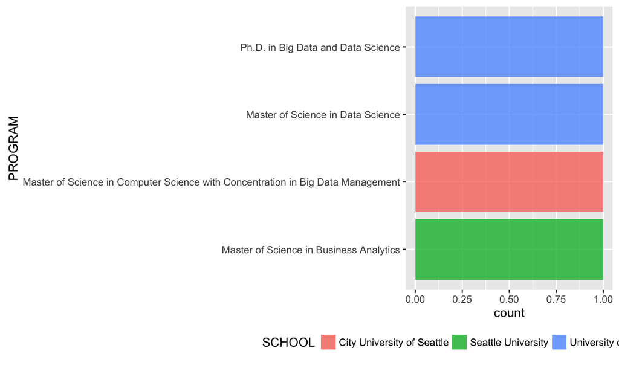

## Shiny app (cont)

Sample output

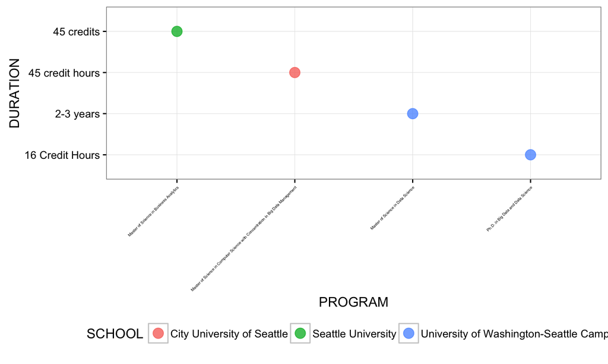